# Various factors influencing BorrowerAPR

## Investigation Overview

In this investigation, I want to look at relationships between various variables with my main interest being 'BorrowerAPR'. I am interested to know about the below:

- Variables that help to decide the Borrower APR while granting a loan
- Identify variables which affect prosper grade for a given borrower.

## Dataset Overview

The dataset consists of around 113937 records and 81 columns. I have created a new dataframe which includes only those records where there is a prosper rating assigned. Hence, the new dataset now has around 84853 records. Also, for the purpose of quality in analysis and visualizations, I have retained only few columns which seemed appropriate.

## Distribution of BorrowerAPR

The Borrower's Annual Percentage Rate (APR) for the loan.

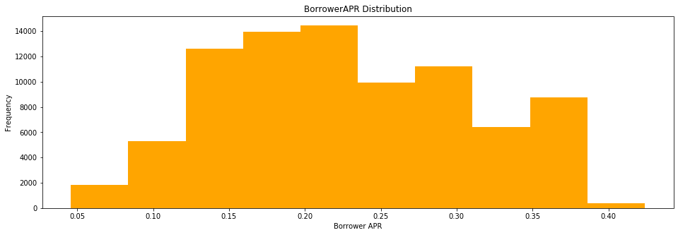

```python
plt.figure(figsize=[16,5])
loan_new['BorrowerAPR'].plot.hist(color='orange')
plt.xlabel('Borrower APR')
plt.title('BorrowerAPR Distribution')
```

## 2. Delinquencies

In the personal finance field, the term "delinquent" commonly refers to a situation where a borrower is late or overdue on a payment, such as income taxes, a mortgage, an automobile loan, or a credit card account.

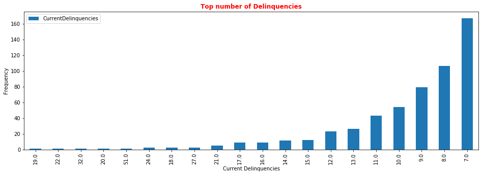

```python
loan1= loan_new[['BorrowerAPR','StatedMonthlyIncome','IncomeRange','IncomeVerifiable','ProsperScore','Occupation','IsBorrowerHomeowner','EmploymentStatusDuration','AmountDelinquent','CurrentDelinquencies','DebtToIncomeRatio','AvailableBankcardCredit','BankcardUtilization']]
plt.figure(figsize=[16,5])
loan1['CurrentDelinquencies'].value_counts().nsmallest(20).plot(kind='bar')
plt.title('Top number of Delinquencies',fontweight='bold',fontsize=12,color='red')
plt.xlabel('Current Delinquencies')
plt.ylabel('Frequency')
plt.legend()
```

From graph 1, We see that there is one account which has a delinquency of 51 followed by 32, 27,24 and so on..

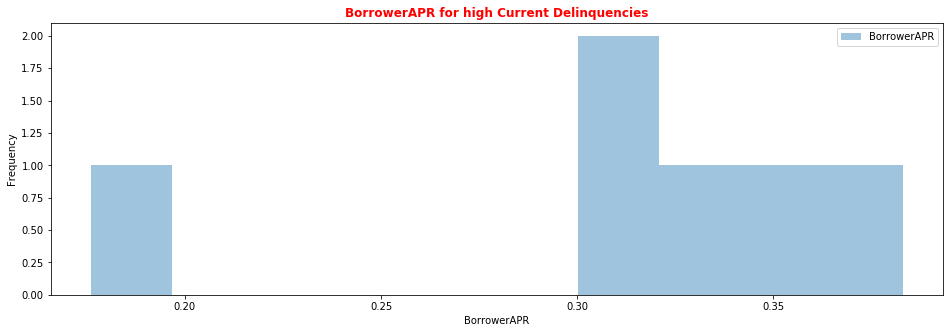

```python
temp=loan1[loan1['CurrentDelinquencies']>22]
temp['BorrowerAPR'].plot.hist(figsize=(16,5),alpha=0.43)
plt.title('BorrowerAPR for high Current Delinquencies',fontweight='bold',color='red')
plt.xlabel('BorrowerAPR')
plt.legend()
```

- From graph 32, we observe that the BorrowerAPR for high current delinquencies lie between 30 and 38% and there is one record which has a borrowerAPR of less that 20%.

## 3. Available Bank card credit

This variable tells the total available credit via bank card at the time the credit profile was pulled.

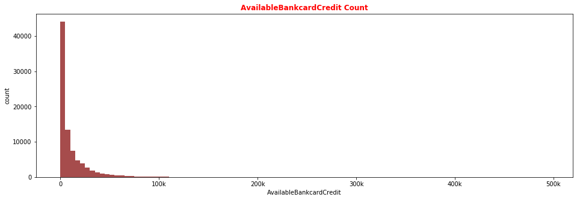

```python
plt.figure(figsize=(16, 5))
bins = np.arange(0,loan_new['AvailableBankcardCredit'].max(), 5000)
plt.hist(data = loan_new, x = 'AvailableBankcardCredit', bins = bins,color='maroon',alpha=0.7)
plt.xticks([0, 1e5, 2e5, 3e5, 4e5, 5e5], [0, '100k', '200k', '300k', '400k', '500k'])
plt.title('AvailableBankcardCredit Count',fontsize=12,fontweight='bold',color='red')
plt.xlabel('AvailableBankcardCredit')
plt.ylabel('count');
```

- Almost everybody's Available bank credit lies between 0 and 100k range. Very few people are present with credit above 100k.

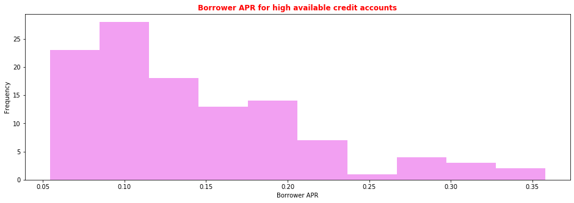

```python
high_credit = loan_new[loan_new['AvailableBankcardCredit'] > 150000]
plt.figure(figsize=(16, 5))
high_credit['BorrowerAPR'].plot.hist(color='violet',alpha=0.76)
plt.title('Borrower APR for high available credit accounts',color='red',fontweight='bold',fontsize=12)
plt.xlabel('Borrower APR')
```

## 4. Prosper Score

It is a custom risk score built using historical Prosper data. The score ranges from 1-10, with 10 being the best, or lowest risk score. Applicable for loans originated after July 2009.

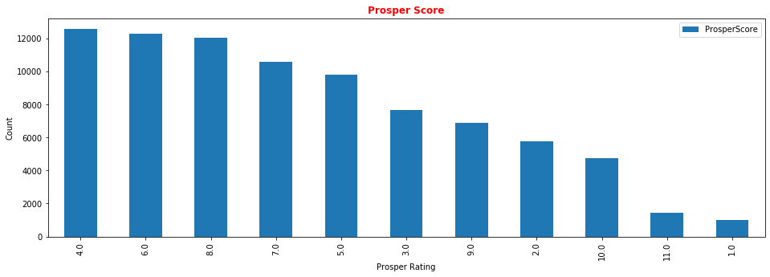

```python
#Visualize prosper score
plt.figure(figsize=(16, 5))
loan_new['ProsperScore'].value_counts().plot(kind='bar')
plt.title('Prosper Score',fontweight='bold',fontsize=12,color='red')
plt.xlabel('Prosper Rating')
plt.ylabel('Count')
plt.legend()
```

From the graph above, we see that majority of the prosper ratings are 4, followed by 6 and 8. There is not much difference in the count of these three ratings.

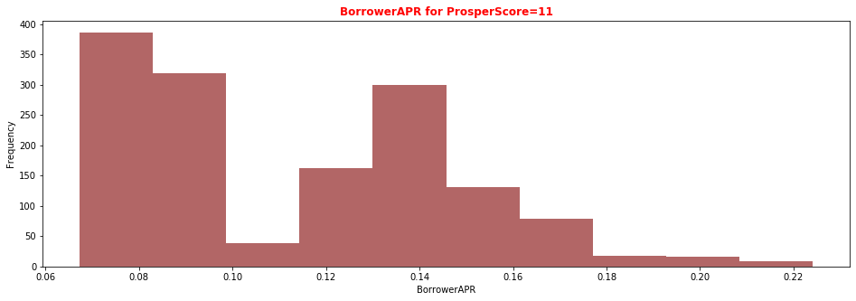

```python
#Fetch records where Prosperscore=11
highprosper=loan_new[loan_new['ProsperScore']==11]
plt.figure(figsize=(16, 5))
highprosper['BorrowerAPR'].plot.hist(color='maroon',alpha=0.6)
plt.title('BorrowerAPR for ProsperScore=11',color='red',fontweight='bold')
plt.xlabel('BorrowerAPR')
```

There are few records as well where the prosper rating is 11. After investigating the records, found that their BorrowerAPR is less comapred to the rest. Their Borrower APR lies between 7 and 23%.

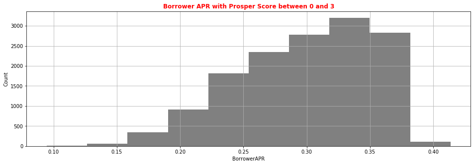

```python
#Fetchvalues between 0 and 4
prosper1=loan_new[loan_new['ProsperScore'].between(0, 3)]
plt.figure(figsize=(16, 5))
prosper1['BorrowerAPR'].hist(color='grey')
plt.title('Borrower APR with Prosper Score between 0 and 3',fontweight='bold',fontsize=12,color='red')
plt.xlabel('BorrowerAPR')
plt.ylabel('Count')
```

- It is clear from this graph that as the prosper score reduces, the BorrowerAPR tends to be high.We see that majority of the people pay a high BorrowerAPR of around 32 to 35%

## Comparing correlations between different numerical variables¶

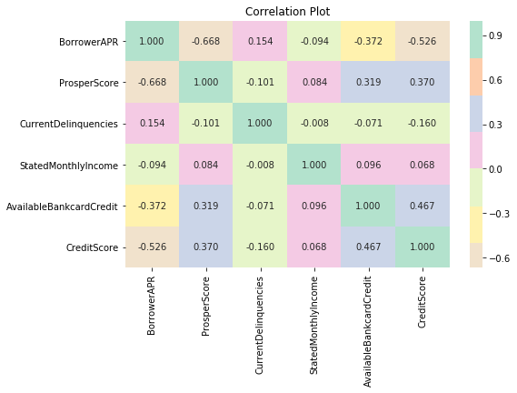

```python
num_vars = ['BorrowerAPR', 'ProsperScore', 'CurrentDelinquencies',
            'StatedMonthlyIncome', 'AvailableBankcardCredit','CreditScore']

plt.figure(figsize = [8, 5])
sns.heatmap(loan_new[num_vars].corr(), annot = True, fmt = '.3f',cmap = 'Pastel2_r', center = 0)
plt.title('Correlation Plot')
plt.show()
```

## 12.Prosper Scores vs Credit Scores

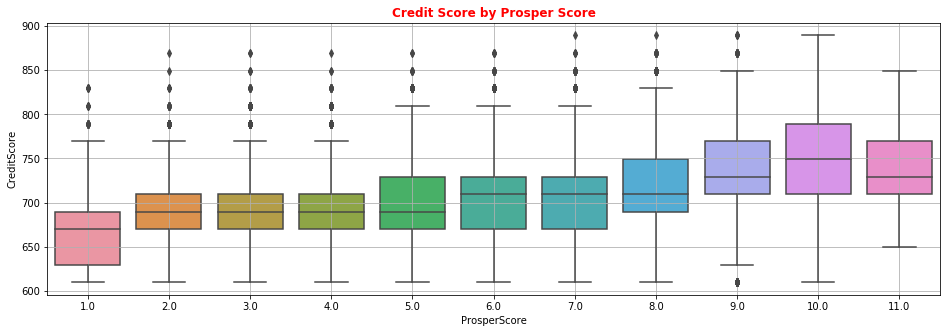

```python
plt.figure(figsize = [16, 5])
sns.boxplot(data=loan_new, x='ProsperScore',y='CreditScore')
plt.title("Credit Score by Prosper Score",color='red',fontsize=12,fontweight='bold')
plt.grid()
```

## 13. BorrowerAPR vs ProsperScore

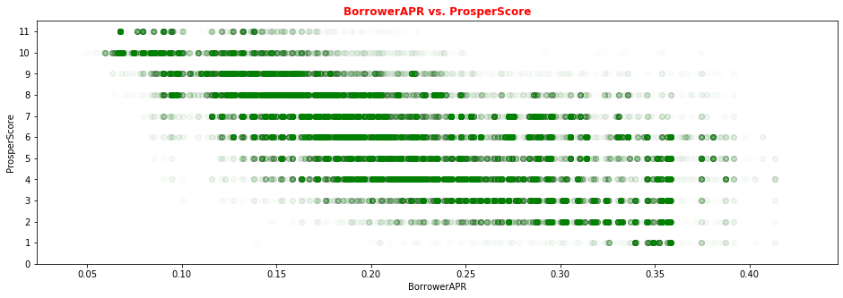

```python
plt.figure(figsize = [16, 5])
plt.scatter(data = loan_new, x = 'BorrowerAPR', y = 'ProsperScore',color='green',alpha=0.007)
plt.yticks(np.arange(0, 12, 1))
plt.title('BorrowerAPR vs. ProsperScore',color='red',fontweight='bold',fontsize=12)
plt.xlabel('BorrowerAPR')
plt.ylabel('ProsperScore')
```

From the graph,it is evident that as Prosper Scores increase, Borrower APR decreases.

## 16. Compare BorrowerAPR wrt ProsperScore and CreditScore

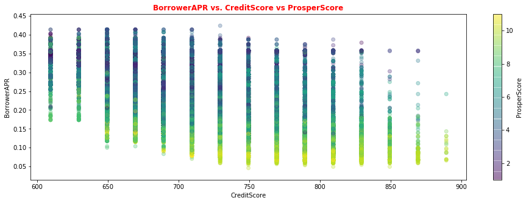

```python
plt.figure(figsize = [16, 5])
plt.scatter(data = loan_new, x = 'CreditScore', y = 'BorrowerAPR',c='ProsperScore', alpha = 0.3)
plt.title('BorrowerAPR vs. CreditScore vs ProsperScore',color='red',fontweight='bold')
plt.xlabel('CreditScore')
plt.colorbar(label = 'ProsperScore')
plt.ylabel('BorrowerAPR');
```

We can infer from the graph as below:

- Comparing CreditScore with BorrowerAPR, we see that as the creditscore increases, BorrowerAPR decreases.
- Now with the Prosper score added, we observe a similar pattern. Looking at the color with yellow being the highest prosper score, we observe that those with higher prosper scores, tend to have lower BorrowerAPR.
- **Conclusion** :Both CreditScore and ProsperScore are negatively correlated to Borrower APR

## BorrowerAPR wrt ProsperGrade and Prosper Rating

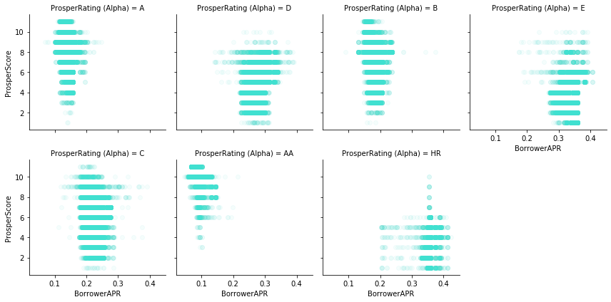

```python
#Visualizing BorrowerAPR and Prosper Score for each prosper Grade
new = sns.FacetGrid(data = loan_new, col = 'ProsperRating (Alpha)', col_wrap = 4, height = 3)
new.map(plt.scatter, 'BorrowerAPR', 'ProsperScore', alpha = 0.05,color='turquoise')
new.set_xlabels('BorrowerAPR')
new.set_ylabels('ProsperScore')
plt.show()
```

## 3. Comparing Employment status wrt BorrowerAPR and Listed Year

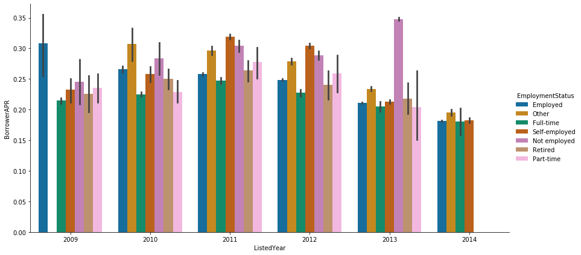

```python
g = sns.factorplot('ListedYear','BorrowerAPR','EmploymentStatus',data=loan_new,kind='bar',height=6,aspect=2,palette='colorblind');
```

From the above plot, we see that in the year 2009, people who were employed paid the highest BorrowerAPR and there was no mention of 'Other' in that year under this category. In the year 2013, 'Not employed seemed to have paid the highest Borrower APR' than the rest. Overall, 2014 saw a decline in the interest paid for all the sectors